# Machine learning Project : Personal Loan Campaign

#### Visualizing the Decision Tree

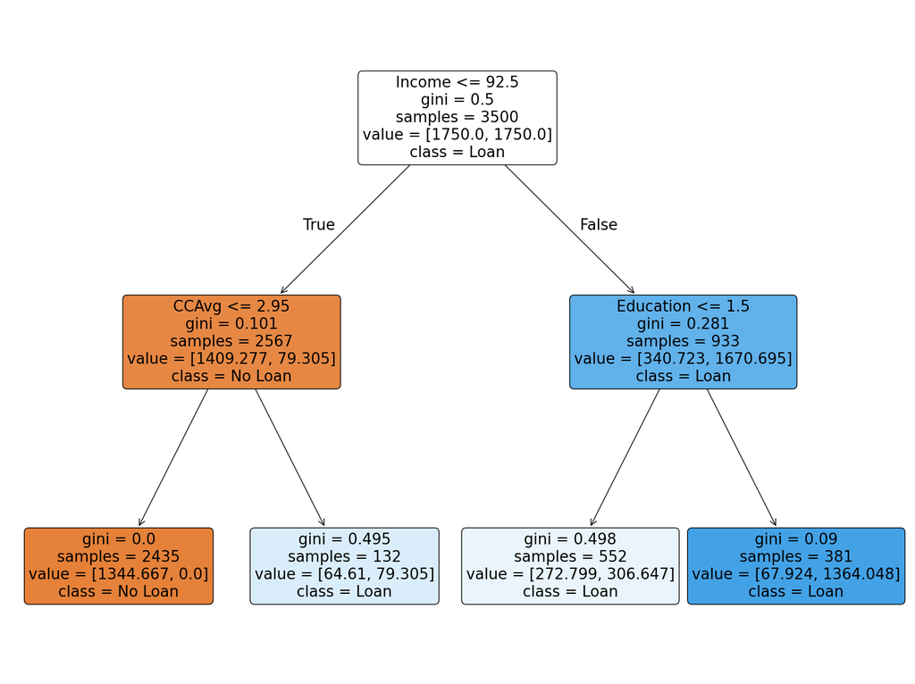

```python
# prompt: code to visualize the decision tree

plt.figure(figsize=(20, 15))
tree.plot_tree(model1, filled=True, feature_names=feature_names, class_names=['No Loan', 'Loan'], rounded=True)
plt.show()
```

```python
# prompt: # Text report showing the rules of a decision tree

print(tree.export_text(model1, feature_names=feature_names, show_weights=True))
```

```
|--- Income <= 92.50
|   |--- CCAvg <= 2.95
|   |   |--- weights: [1344.67, 0.00] class: 0
|   |--- CCAvg >  2.95
|   |   |--- weights: [64.61, 79.31] class: 1
|--- Income >  92.50
|   |--- Education <= 1.50
|   |   |--- weights: [272.80, 306.65] class: 1
|   |--- Education >  1.50
|   |   |--- weights: [67.92, 1364.05] class: 1
```

```
Feature Importances (Pre-pruned Decision Tree):
Income                0.820072
Education             0.117300
CCAvg                 0.062628
Age                   0.000000
ZIPCode               0.000000
Experience            0.000000
Family                0.000000
Mortgage              0.000000
Securities_Account    0.000000
CD_Account            0.000000
Online                0.000000
CreditCard            0.000000
dtype: float64
```

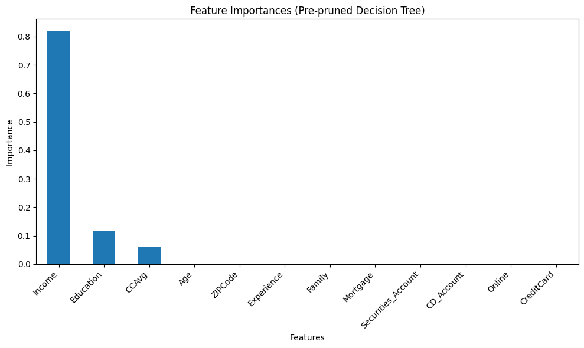

```python
#code to check importanat model features for prepruned model

# Extract feature importances from the trained decision tree model
feature_importances_tuned = model1.feature_importances_

# Create a pandas Series for easier handling and sorting
importance_series_tuned = pd.Series(feature_importances_tuned, index=X_train.columns)

# Sort the features by importance in descending order
sorted_importance_tuned = importance_series_tuned.sort_values(ascending=False)

# Print or visualize the feature importances
print("Feature Importances (Pre-pruned Decision Tree):")
print(sorted_importance_tuned)

# Optional: Plot the feature importances for better visualization
plt.figure(figsize=(10, 6))
sorted_importance_tuned.plot(kind='bar')
plt.title('Feature Importances (Pre-pruned Decision Tree)')
plt.ylabel('Importance')
plt.xlabel('Features')
plt.xticks(rotation=45, ha='right')
plt.tight_layout()
plt.show()
```

Top 3 features are Income, Education and CCAvg.

### Decision Tree (Post pruning)

- Cost complexity pruning provides another option to control the size of a tree.
- In `DecisionTreeClassifier`, this pruning technique is parameterized by the cost complexity parameter, `ccp_alpha`.
- Greater values of `ccp_alpha` increase the number of nodes pruned.
- Here we only show the effect of `ccp_alpha` on regularizing the trees and how to choose the optimal `ccp_alpha` value.

**Total impurity of leaves vs effective alphas of pruned tree**

Minimal cost complexity pruning recursively finds the node with the "weakest link". The weakest link is characterized by an effective alpha, where the nodes with the smallest effective alpha are pruned first. To get an idea of what values of `ccp_alpha` could be appropriate, scikit-learn provides `DecisionTreeClassifier.cost_complexity_pruning_path` that returns the effective alphas and the corresponding total leaf impurities at each step of the pruning process. As alpha increases, more of the tree is pruned, which increases the total impurity of its leaves.

```python
# Fit the Decision Tree classifier to the training data with default parameters and a specified random state for reproducibility.
clf = DecisionTreeClassifier(random_state=1)

# Calculate the pruning path based on cost complexity.
# This function returns the effective alphas and the corresponding total leaf impurities
# at each step of the pruning process.
path = clf.cost_complexity_pruning_path(X_train, y_train)

# Extract the different `ccp_alpha` values from the pruning path.
# These values represent the thresholds for pruning. A higher alpha value results in more pruning.
ccp_alphas, impurities = path.ccp_alphas, path.impurities
```

```python
# Convert the pruning path dictionary to a DataFrame
# The 'path' variable contains the ccp_alphas and corresponding impurities
pd.DataFrame(path)
```

|  | ccp_alphas | impurities |
| --- | --- | --- |
| 0 | 0.000000 | 0.000000 |
| 1 | 0.000223 | 0.001114 |
| 2 | 0.000268 | 0.002188 |
| 3 | 0.000359 | 0.003263 |
| 4 | 0.000381 | 0.003644 |
| 5 | 0.000381 | 0.004025 |
| 6 | 0.000381 | 0.004406 |
| 7 | 0.000381 | 0.004787 |
| 8 | 0.000409 | 0.006423 |
| 9 | 0.000476 | 0.006900 |
| 10 | 0.000508 | 0.007407 |
| 11 | 0.000582 | 0.007989 |
| 12 | 0.000593 | 0.009175 |
| 13 | 0.000641 | 0.011740 |
| 14 | 0.000769 | 0.014817 |
| 15 | 0.000792 | 0.017985 |
| 16 | 0.001552 | 0.019536 |
| 17 | 0.002333 | 0.021869 |
| 18 | 0.003024 | 0.024893 |
| 19 | 0.003294 | 0.028187 |
| 20 | 0.006473 | 0.034659 |
| 21 | 0.023866 | 0.058525 |
| 22 | 0.056365 | 0.171255 |

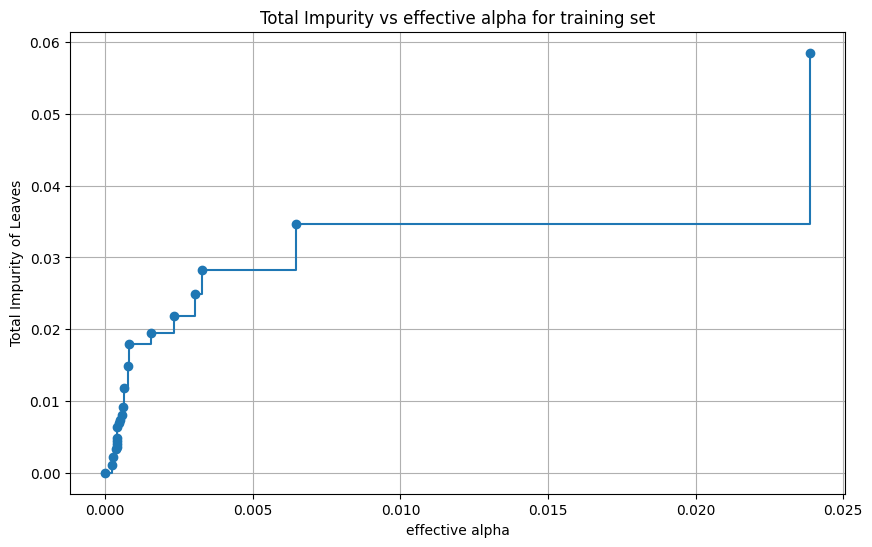

```python
# Plot Total Impurity vs effective alpha for training set
plt.figure(figsize=(10, 6))  # Set the figure size
plt.plot(
    ccp_alphas[:-1],  # Plot ccp_alphas (excluding the last one, which corresponds to the root node)
    impurities[:-1],  # Plot corresponding impurities (excluding the last one)
    marker="o",  # Use circles as markers for data points
    drawstyle="steps-post",  # Draw steps after each point, giving a staircase-like look
)
plt.xlabel("effective alpha")  # Label for the x-axis
plt.ylabel("Total Impurity of Leaves")  # Label for the y-axis
plt.title(
    "Total Impurity vs effective alpha for training set"
)  # Title of the plot
plt.grid(True)  # Add a grid to the plot for better readability
plt.show()  # Display the plot
```

Next, we train a decision tree using the effective alphas. The last value in `ccp_alphas` is the alpha value that prunes the whole tree, leaving the tree, `clfs[-1]`, with one node.

```python
# Train a Decision Tree for each effective alpha value obtained from the pruning path.
# We exclude the last alpha value because it prunes the entire tree to a single node.
clfs = [] # Initialize an empty list to store the trained Decision Tree classifiers
for ccp_alpha in ccp_alphas:
    # Create a Decision Tree Classifier instance with the current ccp_alpha and a fixed random state for reproducibility.
    # class_weight='balanced' can be added here if you want to handle class imbalance during training,
    # but the example code does not include it, so we'll keep it simple for this step.
    clf = DecisionTreeClassifier(random_state=1, ccp_alpha=ccp_alpha)

    # Train the current Decision Tree classifier on the training data (X_train, y_train).
    clf.fit(X_train, y_train)

    # Append the trained classifier to the list of classifiers.
    clfs.append(clf)
print(
    "Number of nodes in the last tree is: {} with ccp_alpha: {}".format(
        clfs[-1].tree_.node_count, ccp_alphas[-1]
    )
)
# Note: clfs[-1] will be the tree trained with the largest ccp_alpha value, which results in a single-node tree (the root node).
# This tree effectively prunes the entire tree and is the result of the final pruning step.
# clfs[0] corresponds to the original, unpruned tree (ccp_alpha=0).
```

```
Number of nodes in the last tree is: 1 with ccp_alpha: 0.056364969335601575
```

For the remainder, we remove the last element in `clfs` and `ccp_alphas`, because it is the trivial tree with only one node. Here we show that the number of nodes and tree depth decreases as alpha increases.

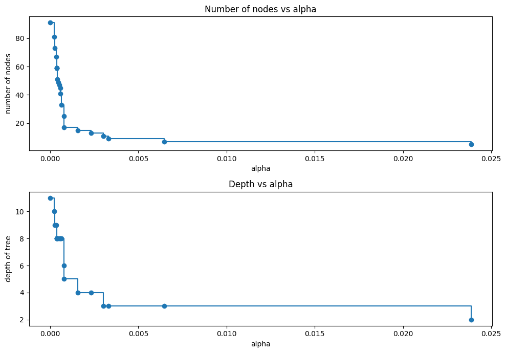

```python
clfs = clfs[:-1]
ccp_alphas = ccp_alphas[:-1]

node_counts = [clf.tree_.node_count for clf in clfs]
depth = [clf.tree_.max_depth for clf in clfs]
fig, ax = plt.subplots(2, 1, figsize=(10, 7))
ax[0].plot(ccp_alphas, node_counts, marker="o", drawstyle="steps-post")
ax[0].set_xlabel("alpha")
ax[0].set_ylabel("number of nodes")
ax[0].set_title("Number of nodes vs alpha")
ax[1].plot(ccp_alphas, depth, marker="o", drawstyle="steps-post")
ax[1].set_xlabel("alpha")
ax[1].set_ylabel("depth of tree")
ax[1].set_title("Depth vs alpha")
fig.tight_layout()
```

#### Recall vs alpha for training and testing sets

```python
# Evaluate recall score for each tree on the training and testing sets
recall_train = []
for clf in clfs:
    # Predict on the training data
    pred_train = clf.predict(X_train)
    # Calculate recall score on the training data
    values_train = recall_score(y_train, pred_train)
    # Append the recall score to the training recall list
    recall_train.append(values_train)
```

```python
recall_test = []
for clf in clfs:
    # Predict on the testing data
    pred_test = clf.predict(X_test)
    # Calculate recall score on the testing data
    values_test = recall_score(y_test, pred_test)
    # Append the recall score to the testing recall list
    recall_test.append(values_test)
```

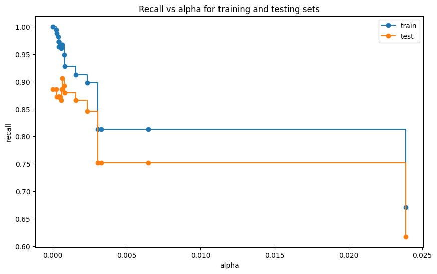

```python
# Plot recall vs alpha for training and testing sets
fig, ax = plt.subplots(figsize=(10, 6))
ax.set_xlabel("alpha")
ax.set_ylabel("recall")
ax.set_title("Recall vs alpha for training and testing sets")
ax.plot(
    ccp_alphas,
    recall_train,
    marker="o",
    label="train",
    drawstyle="steps-post",
)
ax.plot(
    ccp_alphas,
    recall_test,
    marker="o",
    label="test",
    drawstyle="steps-post",
)
ax.legend()
plt.show()
```

```python
# creating the model where we get highest train and test recall
index_best_model = np.argmax(recall_test)
best_model = clfs[index_best_model]
print(best_model)
```

```
DecisionTreeClassifier(ccp_alpha=np.float64(0.0006414326414326415),
                       random_state=1)
```

#### Checking model performance on training set

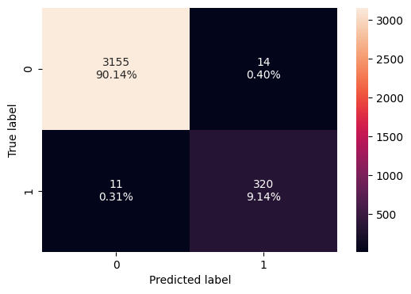

```python
model3 = best_model
confusion_matrix_sklearn(model3, X_train, y_train)
```

```python
decision_tree_postpruned_perf_train = model_performance_classification_sklearn(
    model3, X_train, y_train
)
decision_tree_postpruned_perf_train
```

|  | Accuracy | Recall | Precision | F1 |
| --- | --- | --- | --- | --- |
| 0 | 0.992857 | 0.966767 | 0.958084 | 0.962406 |

#### Checking model performance on test set

```python
decision_tree_postpruned_perf_test = model_performance_classification_sklearn(
    model3, X_test, y_test
)
decision_tree_postpruned_perf_test
```

|  | Accuracy | Recall | Precision | F1 |
| --- | --- | --- | --- | --- |
| 0 | 0.984 | 0.90604 | 0.931034 | 0.918367 |

[figure not shown]

```python
confusion_matrix_sklearn(model3, X_train, y_train)
```

#### Visualizing the Decision Tree

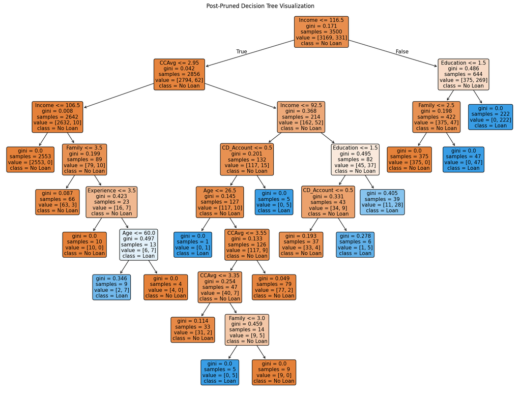

```python
# Visualize the best post-pruned Decision Tree
plt.figure(figsize=(20, 15)) # Set the figure size for better visibility
# Use plot_tree function to visualize the tree
tree.plot_tree(
    model3, # The trained Decision Tree model (the best post-pruned model)
    filled=True, # Fill nodes with colors to indicate the majority class
    feature_names=feature_names, # Use actual feature names from the data
    class_names=['No Loan', 'Loan'], # Use meaningful class names for the target variable
    rounded=True # Draw nodes with rounded corners
)
plt.title('Post-Pruned Decision Tree Visualization') # Add a title to the plot
plt.show() # Display the plot
```

```python
# Print the text representation of the tree
print(tree.export_text(model3, feature_names=feature_names, show_weights=True))
```

```
|--- Income <= 116.50
|   |--- CCAvg <= 2.95
|   |   |--- Income <= 106.50
|   |   |   |--- weights: [2553.00, 0.00] class: 0
|   |   |--- Income >  106.50
|   |   |   |--- Family <= 3.50
|   |   |   |   |--- weights: [63.00, 3.00] class: 0
|   |   |   |--- Family >  3.50
|   |   |   |   |--- Experience <= 3.50
|   |   |   |   |   |--- weights: [10.00, 0.00] class: 0
|   |   |   |   |--- Experience >  3.50
|   |   |   |   |   |--- Age <= 60.00
|   |   |   |   |   |   |--- weights: [2.00, 7.00] class: 1
|   |   |   |   |   |--- Age >  60.00
|   |   |   |   |   |   |--- weights: [4.00, 0.00] class: 0
|   |--- CCAvg >  2.95
|   |   |--- Income <= 92.50
|   |   |   |--- CD_Account <= 0.50
|   |   |   |   |--- Age <= 26.50
|   |   |   |   |   |--- weights: [0.00, 1.00] class: 1
|   |   |   |   |--- Age >  26.50
|   |   |   |   |   |--- CCAvg <= 3.55
|   |   |   |   |   |   |--- CCAvg <= 3.35
|   |   |   |   |   |   |   |--- weights: [31.00, 2.00] class: 0
|   |   |   |   |   |   |--- CCAvg >  3.35
|   |   |   |   |   |   |   |--- Family <= 3.00
|   |   |   |   |   |   |   |   |--- weights: [0.00, 5.00] class: 1
|   |   |   |   |   |   |   |--- Family >  3.00
|   |   |   |   |   |   |   |   |--- weights: [9.00, 0.00] class: 0
|   |   |   |   |   |--- CCAvg >  3.55
|   |   |   |   |   |   |--- weights: [77.00, 2.00] class: 0
|   |   |   |--- CD_Account >  0.50
|   |   |   |   |--- weights: [0.00, 5.00] class: 1
|   |   |--- Income >  92.50
|   |   |   |--- Education <= 1.50
|   |   |   |   |--- CD_Account <= 0.50
|   |   |   |   |   |--- weights: [33.00, 4.00] class: 0
|   |   |   |   |--- CD_Account >  0.50
|   |   |   |   |   |--- weights: [1.00, 5.00] class: 1
|   |   |   |--- Education >  1.50
|   |   |   |   |--- weights: [11.00, 28.00] class: 1
|--- Income >  116.50
|   |--- Education <= 1.50
|   |   |--- Family <= 2.50
|   |   |   |--- weights: [375.00, 0.00] class: 0
|   |   |--- Family >  2.50
|   |   |   |--- weights: [0.00, 47.00] class: 1
|   |--- Education >  1.50
|   |   |--- weights: [0.00, 222.00] class: 1
```

```
Feature Importances (Post-pruned Decision Tree):
Education             0.430462
Income                0.319735
Family                0.165225
CCAvg                 0.045288
CD_Account            0.024353
Age                   0.009066
Experience            0.005871
ZIPCode               0.000000
Mortgage              0.000000
Securities_Account    0.000000
Online                0.000000
CreditCard            0.000000
dtype: float64
```

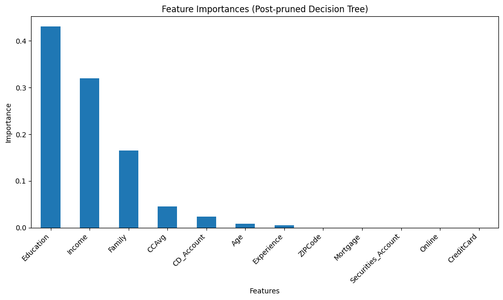

```python
# Extract feature importances from the best post-pruned model
feature_importances_postpruned = model3.feature_importances_

# Create a pandas Series for easier handling and sorting
importance_series_postpruned = pd.Series(feature_importances_postpruned, index=X_train.columns)

# Sort the features by importance in descending order
sorted_importance_postpruned = importance_series_postpruned.sort_values(ascending=False)

# Print the feature importances
print("Feature Importances (Post-pruned Decision Tree):")
print(sorted_importance_postpruned)

# Plot the feature importances for better visualization
plt.figure(figsize=(10, 6))
sorted_importance_postpruned.plot(kind='bar')
plt.title('Feature Importances (Post-pruned Decision Tree)')
plt.ylabel('Importance')
plt.xlabel('Features')
plt.xticks(rotation=45, ha='right')
plt.tight_layout()
plt.show()
```

Education, income and family becomes the top 3 features with post pruning.

### Model Performance Comparison and Final Model Selection

```python
# training performance comparison

models_train_comp_df = pd.concat(
    [
        decision_tree_default_perf_train.T,
        decision_tree_tune_perf_train.T,
        decision_tree_postpruned_perf_train.T,
    ],
    axis=1,
)
models_train_comp_df.columns = [
    "Decision Tree (sklearn default)",
    "Decision Tree (Pre-Pruning)",
    "Decision Tree (Post-Pruning)",
]
print("Training performance comparison:")
models_train_comp_df
```

```
Training performance comparison:
```

|  | Decision Tree (sklearn default) | Decision Tree (Pre-Pruning) | Decision Tree (Post-Pruning) |
| --- | --- | --- | --- |
| Accuracy | 1.0 | 0.790286 | 0.992857 |
| Recall | 1.0 | 1.000000 | 0.966767 |
| Precision | 1.0 | 0.310798 | 0.958084 |
| F1 | 1.0 | 0.474212 | 0.962406 |

```python
# test performance comparison

models_train_comp_df = pd.concat(
    [
        decision_tree_default_perf_test.T,
        decision_tree_tune_perf_test.T,
        decision_tree_postpruned_perf_test.T,
    ],
    axis=1,
)
models_train_comp_df.columns = [
    "Decision Tree (sklearn default)",
    "Decision Tree (Pre-Pruning)",
    "Decision Tree (Post-Pruning)",
]
print("Test set performance comparison:")
models_train_comp_df
```

```
Test set performance comparison:
```

|  | Decision Tree (sklearn default) | Decision Tree (Pre-Pruning) | Decision Tree (Post-Pruning) |
| --- | --- | --- | --- |
| Accuracy | 0.980000 | 0.779333 | 0.984000 |
| Recall | 0.885906 | 1.000000 | 0.906040 |
| Precision | 0.910345 | 0.310417 | 0.931034 |
| F1 | 0.897959 | 0.473768 | 0.918367 |

**Evaluation based on Objective (Maximizing Recall):**

The problem statement emphasizes identifying customers most likely to take personal loans, which means minimizing False Negatives. Therefore, Recall is the most critical metric.

**Pre-Pruning:** Achieves perfect Recall (1.0) on both training and test sets. This means it identifies all customers who took a personal loan in the test set. However, its Precision is very low (0.310), meaning for every 10 customers it predicts will take a loan, only about 3 actually do. This would lead to significant wasted resources in targeting.

**Post-Pruning**: Achieves a high Recall (0.906) on the test set, which means it identifies about 90.6% of the actual loan takers. Its Precision is also high (0.931), meaning when it predicts someone will take a loan, it's correct about 93.1% of the time.

**Conclusion:**

While the **Decision Tree (Pre-Pruning)** model achieves the highest Recall (1.0) on the test set, its extremely low Precision makes it impractical. The bank would be targeting a huge number of customers who will not take a loan, leading to significant marketing costs.

The **Decision Tree (Post-Pruning)** model offers a better balance between Recall and Precision on the test set. It identifies a large proportion of the actual loan takers (high Recall of 0.906) while also being relatively accurate in its positive predictions (high Precision of 0.931). This leads to a higher F1 score (0.918), which is the harmonic mean of Recall and Precision and provides a better overall measure of the model's performance for imbalanced datasets where both false positives and false negatives have costs.

The **Decision Tree (sklearn default)** model clearly overfits and performs worse than the post-pruned model on the test set.

Therefore, based on the objective of identifying potential loan takers efficiently (considering both finding them and not wasting resources on false positives), **the Decision Tree (Post-Pruning) model is the better choice**. It offers a strong balance of identifying most loan takers while maintaining a reasonable level of precision in its targeting.

### Key Takeaways for the Marketing Team & Advice for the Campaign:

Based on the data analysis and the performance of the chosen Post-Pruned Decision Tree model (Recall: ~0.91, Precision: ~0.93 on the test set), here are the key takeaways and advice for the personal loan campaign:

1. **Target the Right Customer Segments:** The model identifies customers most likely to accept a personal loan. Do NOT use a blanket approach. Focus your marketing efforts and resources on the customers identified as potential loan takers by the model. This will significantly increase your conversion rate compared to the previous campaign's 9%.
2. **Prioritize Based on Key Attributes:** The most influential factors in predicting loan acceptance are:
   - **Income:** Customers with higher incomes are significantly more likely to take a loan.
   - **Education Level:** Customers with an 'Advanced/Professional' education are more prone to taking loans.
   - **Family Size:** Customers with a family size of 4 show a higher propensity for loan uptake.
   - **CCAvg (Average Credit Card Spending):** Customers with higher average monthly credit card spending are also more likely candidates.
   - **CD Account:** Customers who already have a CD account with the bank are more likely to accept a personal loan offer.
3. **Tailor Your Messaging:**
   - Highlight the benefits of a personal loan in relation to **high income** and **spending habits**. Position the loan as a way to manage finances better, invest, or fulfill aspirations for those with higher incomes and spending.
   - For customers with **'Advanced/Professional' education**, tailor the message to appeal to their financial sophistication and potential need for capital for professional or personal growth.
   - Consider messaging that resonates with **larger families (size 4)**, potentially focusing on needs like home improvements, education expenses, or consolidating debts.
   - Leverage the fact that customers with a **CD Account** are likely to be financially engaged. Position the personal loan as another valuable financial product from the bank they already trust.
4. **Utilize the Model for High-Probability Leads:** The post-pruned decision tree model achieved a good balance of identifying about 90.6% of actual loan takers (high Recall) while being correct in its positive predictions about 93.1% of the time (high Precision). This means the list of customers the model predicts will take a loan is highly reliable. Focus initial and most intensive marketing efforts on this list.
5. **Optimize Resource Allocation:** By targeting only the high-probability leads identified by the model, the bank can drastically reduce wasted marketing spend on customers who are unlikely to convert. This allows for more effective use of budget on personalized outreach, higher-quality marketing materials, or even special offers for the targeted segment.
6. **Consider Channel Strategy:** Analyze which channels (email, mail, in-branch, online ads) are most effective for these specific customer segments based on their demographics (age, online usage) and existing relationships (CD account holders, credit card users).
7. **Continuous Monitoring and Refinement:** This model is a starting point. Continuously track the conversion rate of the targeted customers. Collect feedback from the marketing team and sales channels. Use the results of this campaign to refine the model and targeting strategy for future campaigns.

In summary, the advice is to shift from a broad marketing campaign to a **highly targeted, data-driven approach**. Use the insights from the model, particularly the importance of Income, Education (Adv/Prof), Family size 4, CCAvg, and CD Account, to identify the most promising customers and tailor the marketing message to resonate with their specific financial profiles and needs. The post-pruned decision tree model provides the predicted customer list to achieve this efficient targeting.

## Conclusion and Recommendations

**Recommendations:**

1. **Targeted Marketing Campaigns:** The bank should focus its personal loan marketing efforts on customer segments identified as most likely to accept:
   - Customers with **high income** and **high average credit card spending**.
   - Customers with **'Advanced/Professional' education**.
   - Customers who currently hold a **CD Account** with the bank.
   - Customers with a **family size of 4**.
2. **Leverage Customer Data:** Utilize existing customer data on income, CCAvg, education level, family size, and CD account status to identify and prioritize high-potential leads for personal loan offers.
3. **Refine Offers:** Tailor personal loan offers based on customer segments. For instance, offers to high-income, high-spending customers might focus on larger loan amounts or premium features, while offers to customers with CD accounts could highlight synergies or bundled benefits.
4. **Explore Feature Interactions:** While Income and CCAvg are strong individual predictors, the multivariate analysis (e.g., Income vs. Education colored by loan status) suggests that interactions between features are also important. Future analysis or models could explicitly capture these interactions for potentially better predictions.
5. **Monitor and Iterate:** Implement the model's recommendations for targeted campaigns and continuously monitor the conversion rates. Use feedback from campaigns to refine the model and targeting strategy over time.

By implementing these recommendations, All Life Bank can significantly improve the efficiency and success rate of its personal loan campaigns by focusing resources on the customers most likely to convert.